# 1)

### ---> Bayes’ Theorem shows us how to turn P(E|H) to P(H|E), with E=Evidence and H=Hypothesis. But what does that really mean? Imagine you have to explain this to someone who doesn't understand machine learning or probability at all.

## 1A Explain how to turn P(E|H) to P(H|E), with E=Evidence and H=Hypothesis in layman's terms

Steps:

1. Initially : Think of the initial hypothesis we need to predict (assuming an equal proability of previous hypothesis happening)
2. Apply bayes theorem to update our perspective on the hypoethesis being true based on specific evidence shown. --Bayes Theorem: P(H|E) = P(E|H) * P(H) / P(E)

It allows us to change our starting confidence based on updated evidence that allows us to change how we perceive/predict things now. New evidence is shown which changes our perspective, Updated information helps us change our perspective. Based on previous evdience shown, you have an initial prediction(Hypothesis) on whats coming. But now you're given supported/updated information causing you now to hypothesize something else, and now want to see if your hypothesis has come true. given the new,current evidence (P(H|E))

Steps:

```
1. Prior P(H)
    -This is your starting belief of a hypothesis before taking into account of new evidence showcased
2. Likelihood P(E|H)
    -The chance of seeing the evidence if the hypothesis holds true
3. Posterior P(H|E)
    -This is now your adapted(updated) belief now folllowing the hypothesis after you take into consideration the new evidence shown
```

To convert from P(E|H) to P(H|E), the conversion factor pursues updating our starting belief P(H) based on new evidence P(E) shown. Bayes theorem acts as the conversion factor to convert our starting belief from the likelihood to end up updating into the posterior.

## 1B - Use an example from real life to ground the explanation.

The answer should be no more than two paragraphs. (-1 pt if longer than two paragraphs.)

Weather forecast scenario:

-Focus on the prior: itS Not raining and cloudy

Say there's a scenario of you wanting to go on a run in summer thinking temperatures were hot(Hypothesis = Thinking It was hot), so you wear a short sleeve outfit. Now you check the weather, and using its forecast of sunshine, you can tell that it's going to be a hot day (P(Evidence|Hypothesis)). When leaving the house, you begin to see clouds appearing(New Evidence). Now you hypothesize that “how does this change the likelihood of it being hot?” (H). Initially we thought it was going to be hot due to sunshine but with the appearance of clouds (New Evidence), I’m now interested in the chance of it being hot P(H|E)

# 2)

```python
import csv
from textblob import TextBlob
import _pickle as cPickle

from sklearn.feature_extraction.text import CountVectorizer, TfidfTransformer
from sklearn.naive_bayes import MultinomialNB
from sklearn.svm import SVC, LinearSVC
from sklearn.metrics import classification_report, f1_score, accuracy_score, confusion_matrix
from sklearn.pipeline import Pipeline
from sklearn.model_selection import GridSearchCV
from sklearn.model_selection import StratifiedKFold, cross_val_score, train_test_split
from sklearn.tree import DecisionTreeClassifier
from sklearn.model_selection import learning_curve
from sklearn.neighbors import KNeighborsClassifier
from sklearn.model_selection import KFold, cross_validate # for Cross-validation
from sklearn.tree import DecisionTreeClassifier
from sklearn import tree, ensemble

import matplotlib.pyplot as plt
from sklearn import datasets, linear_model
from sklearn.metrics import mean_squared_error, r2_score
from sklearn.preprocessing import StandardScaler
from sklearn.model_selection import train_test_split
from sklearn.linear_model import SGDRegressor
from sklearn.pipeline import make_pipeline
import seaborn as sns


import matplotlib.pyplot as plt
import numpy as np
import pandas as pd
import mlxtend
```

## 2A - For this exercise use any four of these five datasets to build a spam filter with the Naïve Bayes approach.

### Read Data and split into training/test sets

```python
#Concatenate 4 datasets into a traiining set = 80%
#Use last dataset as a test set

#Dataset 1

df1 = pd.read_csv('/Users/carloscura/Downloads/YouTube-Spam-Collection-v1/Youtube01-Psy.csv')

#Dataset 2
df2 = pd.read_csv('/Users/carloscura/Downloads/YouTube-Spam-Collection-v1/Youtube02-KatyPerry.csv')
#Dataset 3
df3 = pd.read_csv('/Users/carloscura/Downloads/YouTube-Spam-Collection-v1/Youtube03-LMFAO.csv')
#Dataset 4
df4 = pd.read_csv('/Users/carloscura/Downloads/YouTube-Spam-Collection-v1/Youtube04-Eminem.csv')

#TrainingSet
trainingDF = pd.concat([df1, df2, df3, df4], ignore_index=True)
trainingDF

#TestSet
testDF = pd.read_csv('/Users/carloscura/Downloads/YouTube-Spam-Collection-v1/Youtube05-Shakira.csv')
testDF
```

|  | COMMENT_ID | AUTHOR | DATE | CONTENT | CLASS |
| --- | --- | --- | --- | --- | --- |
| 0 | z13lgffb5w3ddx1ul22qy1wxspy5cpkz504 | dharma pal | 2015-05-29T02:30:18.971000 | Nice song | 0 |
| 1 | z123dbgb0mqjfxbtz22ucjc5jvzcv3ykj | Tiza Arellano | 2015-05-29T00:14:48.748000 | I love song  | 0 |
| 2 | z12quxxp2vutflkxv04cihggzt2azl34pms0k | Prìñçeśś Âliś Łøvê Dømíñø Mâđiś™  | 2015-05-28T21:00:08.607000 | I love song  | 0 |
| 3 | z12icv3ysqvlwth2c23eddlykyqut5z1h | Eric Gonzalez | 2015-05-28T20:47:12.193000 | 860,000,000 lets make it first female to reach... | 0 |
| 4 | z133stly3kete3tly22petvwdpmghrlli | Analena López | 2015-05-28T17:08:29.827000 | shakira is best for worldcup | 0 |
| ... | ... | ... | ... | ... | ... |
| 365 | _2viQ_Qnc6-bMSjqyL1NKj57ROicCSJV5SwTrw-RFFA | Katie Mettam | 2013-07-13T13:27:39.441000 | I love this song because we sing it at Camp al... | 0 |
| 366 | _2viQ_Qnc6-pY-1yR6K2FhmC5i48-WuNx5CumlHLDAI | Sabina Pearson-Smith | 2013-07-13T13:14:30.021000 | I love this song for two reasons: 1.it is abou... | 0 |
| 367 | _2viQ_Qnc6_k_n_Bse9zVhJP8tJReZpo8uM2uZfnzDs | jeffrey jules | 2013-07-13T12:09:31.188000 | wow | 0 |
| 368 | _2viQ_Qnc6_yBt8UGMWyg3vh0PulTqcqyQtdE7d4Fl0 | Aishlin Maciel | 2013-07-13T11:17:52.308000 | Shakira u are so wiredo | 0 |
| 369 | _2viQ_Qnc685RPw1aSa1tfrIuHXRvAQ2rPT9R06KTqA | Latin Bosch | 2013-07-12T22:33:27.916000 | Shakira is the best dancer | 0 |

370 rows × 5 columns

### Data preprocessing

```python
def split_into_tokens(CONTENT):
    return TextBlob(CONTENT).words
trainingDF.CONTENT.apply(split_into_tokens)
```

```
0       [Huh, anyway, check, out, this, you, tube, cha...
1       [Hey, guys, check, out, my, new, channel, and,...
2         [just, for, test, I, have, to, say, murdev.com]
3       [me, shaking, my, sexy, ass, on, my, channel, ...
4             [watch, v=vtaRGgvGtWQ, Check, this, out, ]
                              ...
1581       [SUBSCRIBE, TO, MY, CHANNEL, X, PLEASE, SPARE]
1582    [Check, out, my, videos, guy, Hope, you, guys,...
1583    [3, yrs, ago, I, had, a, health, scare, but, t...
1584    [Rihanna, looks, so, beautiful, with, red, hai...
1585                     [857.482.940, views, AWESOME, ]
Name: CONTENT, Length: 1586, dtype: object
```

```python
def split_into_lemmas(CONTENT):
    CONTENT = CONTENT.lower()
    words = TextBlob(CONTENT).words
    # for each word, take its "base form" = lemma
    return [word.lemma for word in words]

trainingDF.CONTENT.apply(split_into_lemmas)
```

```
0       [huh, anyway, check, out, this, you, tube, cha...
1       [hey, guy, check, out, my, new, channel, and, ...
2         [just, for, test, i, have, to, say, murdev.com]
3       [me, shaking, my, sexy, as, on, my, channel, e...
4             [watch, v=vtarggvgtwq, check, this, out, ]
                              ...
1581       [subscribe, to, my, channel, x, please, spare]
1582    [check, out, my, video, guy, hope, you, guy, h...
1583    [3, yr, ago, i, had, a, health, scare, but, th...
1584    [rihanna, look, so, beautiful, with, red, hair...
1585                      [857.482.940, view, awesome, ]
Name: CONTENT, Length: 1586, dtype: object
```

```python
bow_transformer = CountVectorizer(analyzer=split_into_lemmas).fit(trainingDF['CONTENT'])
print (len(bow_transformer.vocabulary_))
```

```
3897
```

```python
messages_bow = bow_transformer.transform(trainingDF['CONTENT'])
tfidf_transformer = TfidfTransformer().fit(messages_bow)
```

```python
#def split_into_lemmas(CONTENT):
  #  CONTENT = CONTENT.lower()
   # words = TextBlob(CONTENT).words
   # return [word.lemma for word in words]
```

```python
bow_transformer = CountVectorizer(analyzer=split_into_lemmas).fit(trainingDF['CONTENT'])
```

```python
#Split training/set
X_train = trainingDF['CONTENT']
Y_train = trainingDF['CLASS']

X_test = testDF['CONTENT']
Y_test = testDF['CLASS']

#meesage column = CONTENT column
#label column = CLASS column
```

### Training

#### Apply pipeline & Make predictions

```python
pipeline = Pipeline([
    ('bow', CountVectorizer(analyzer=split_into_lemmas)),
    ('tfidf', TfidfTransformer()),  # integer counts to weighted TF-IDF scores
    ('classifier', MultinomialNB()),  # train on TF-IDF vectors w/ Naive Bayes classifier
])
```

```python
pipeline.fit(X_train, Y_train)
```

```
Pipeline(steps=[('bow',
                 CountVectorizer(analyzer=<function split_into_lemmas at 0x7ff5391c2160>)),
                ('tfidf', TfidfTransformer()),
                ('classifier', MultinomialNB())])
```

```python
trainingSetPred = pipeline.predict(X_train)
```

#### Find its accuracy

```python
trainingSetAccuracy = accuracy_score(Y_train, trainingSetPred)
print(trainingSetAccuracy)
#97% accurate
```

```
0.9709962168978562
```

## 2B - Use that filter to check the accuracy on the remaining dataset

#### Apply pipeline & Make predictions

```python
X_test = testDF['CONTENT']
Y_test = testDF['CLASS']
```

```python
testSetPred = pipeline.predict(X_test)
```

#### Find its accuracy

```python
testSetAccuracy = accuracy_score(Y_test, testSetPred)
print(testSetAccuracy)
#84% accurate
```

```
0.8486486486486486
```

-Collect the features from all 5 datasets -Train the classifier -process the features

## -Be careful using tfidf and bag of words

## 2C - Make sure to report the details of the training process and the model

### Visualization

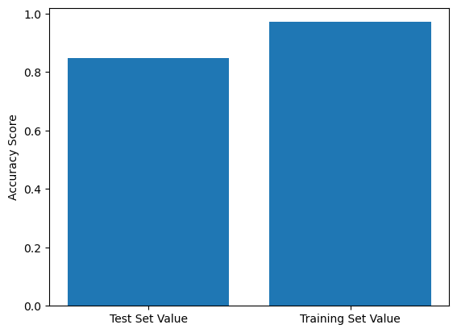

```python
plt.bar(['Test Set Value', 'Training Set Value'], [testSetAccuracy, trainingSetAccuracy])
plt.ylabel('Accuracy Score')
```

### Report

#### Introduction:

- In order to represent a train/test split I combined 4 datasets together(representing my 80% for training) and leaving 1 dataset untouched(representing my test set (20%))

#### Data preprocessing:

- I applied the bag-of-words method to transform raw text data is the input into into an unordered structure for language processing
- I applied token splits to divide sentences into individual words using the function 'def split_into_tokens' using the training dataset
- I then normalized each word into its base form (lemmazation) using the function 'def split_into_lemmas' to make sure grammar forms for each words various forms are treated as the same
- I then vectorized my words so machine learning models can understand and analyze but also applying the frqeuency of words (tfidfTransformer).

  ```
    --I also used Multinomial classification to account for its use in the bag-of-words method since text-processing is distributed
  ```

- I then applied a pipeline for trial & error purposes to ensure my functions for text processing was working

#### Modeling:

- I then used the pipeline to fit & train my model using the training set to learn patterns and predictions afterwards(pipeline.predict(X_train))
- Then I applied the accuracy score to my classifcation label and predictions to find out its performance
- SAME EXACT STEPS I THEN APPLIED FOR TEST SET

#### Results:

- I attained an accuracy score of 84% on my test set and 97% on my training set

#### Analysis:

- My accuracy score on my test set being lower than my training set may be accounted for due to overfitting for my training set as noise has been accounted for since it is larger
- My test set is also small compared to my training set so the model may have accounyrf for various patterns that hasnt been seen in the training set causing a lower accuracy

# 3)

```python
#The pd.read_fwf() function provides the functionality to read fixed-width file formats.
```

```python
Portugesedata = pd.read_fwf('/Users/carloscura/Downloads/armada.dat.txt', sep=",", header = None)
Portugesedata.columns = ["Battle", "Year", "Portugese Ships", "Dutch Ships", "English Ships", "The ratio of Portuguese to Dutch/British Ships", "Spanish Involvement", "Portuguese outcome"]
Portugesedata.dropna()
Portugesedata.head(10)
#Spanish Involvement: 1=Yes, 0=No
#Portugese Outcome: -1=Defeat, 0=Draw, 1=Victory
#
```

|  | Battle | Year | Portugese Ships | Dutch Ships | English Ships | The ratio of Portuguese to Dutch/British Ships | Spanish Involvement | Portuguese outcome |
| --- | --- | --- | --- | --- | --- | --- | --- | --- |
| 0 | Bantam | 1601 | 6 | 3 | 0 | 2.000 | 0 | 0 |
| 1 | Malacca Strait | 1606 | 14 | 11 | 0 | 1.273 | 0 | 0 |
| 2 | Ilha das Naus | 1606 | 6 | 9 | 0 | 0.667 | 0 | -1 |
| 3 | Pulo Butum | 1606 | 7 | 9 | 0 | 0.778 | 0 | 1 |
| 4 | Surrat | 1615 | 6 | 0 | 4 | 1.500 | 0 | 0 |
| 5 | Ilha das Naus | 1615 | 3 | 5 | 0 | 0.600 | 0 | -1 |
| 6 | Jask | 1620 | 4 | 0 | 4 | 1.000 | 0 | 0 |
| 7 | Hormuz | 1622 | 6 | 0 | 5 | 1.200 | 0 | -1 |
| 8 | Mogincoal Shoals | 1622 | 4 | 4 | 2 | 0.667 | 0 | -1 |
| 9 | Hormuz | 1625 | 8 | 4 | 4 | 1.000 | 0 | 0 |

## 3A - Use an SVM-based model to predict the Portuguese outcome of the battle from the number of ships involved on all sides and Spanish involvement

```python
#Support vector machine
#Ships involved from all sides
#Spanish involvement
```

```python
import pandas as pd
from sklearn.model_selection import train_test_split
from sklearn.metrics import accuracy_score, confusion_matrix, classification_report
from sklearn.svm import SVC

X = Portugesedata[["Portugese Ships", "Dutch Ships", "English Ships","Spanish Involvement" ]]
y = Portugesedata['Portuguese outcome']
X_train,X_test,y_train,y_test = train_test_split(X, y, test_size=0.2)

model = SVC(C=1000, kernel='rbf' )
model.fit(X_train,y_train)
predictions = model.predict(X_train)
print("Training accuracy:", accuracy_score(y_train,predictions))
print(model.score(X_train, y_train))
predictions = model.predict(X_test)
print("Test accuracy:", accuracy_score(y_test,predictions))
```

```
Training accuracy: 0.8181818181818182
0.8181818181818182
Test accuracy: 0.5
```

## 3B - Try solving the same problem using two other classifiers that you know

# Decision Trees

```python
##Split into trainding/valid data sets

knn = KNeighborsClassifier(n_neighbors=10)
x_cols2 = ["Portugese Ships", "Dutch Ships", "English Ships","Spanish Involvement"]


y_cols2 = ['Portuguese outcome']
#Change feature to categorical outcome

X_full2 = Portugesedata[x_cols2]

y_full2 = Portugesedata[y_cols2]


X_train, X_test, y_train, y_test = train_test_split(X_full2, y_full2, test_size=0.2, random_state=42)
```

```python
results_trainList = []
results_testList = []

from sklearn.model_selection import LeaveOneOut

stratfieldFold = LeaveOneOut()

for depth in range(1,10,1):
    np.random.seed(1000)
    clf_dt = make_pipeline( StandardScaler(), tree.DecisionTreeClassifier(max_depth=depth))

    clf_dt.fit(X_train, y_train)


    accuracy_resultsTrain =  clf_dt.score(X_train, y_train)
    accuracy_resultsTest =  clf_dt.score(X_test, y_test)

    results_trainList.append([depth, 100 * np.mean(accuracy_resultsTrain)])


    results_testList.append([depth, 100 * np.mean(accuracy_resultsTest)])


df_results_list_dtTrain2 = pd.DataFrame(results_trainList, columns=["Max_Depth", "Acc"])
df_results_list_dtTest2 = pd.DataFrame(results_testList, columns=["Max_Depth", "Acc"])
```

## Decision Tree Visualization

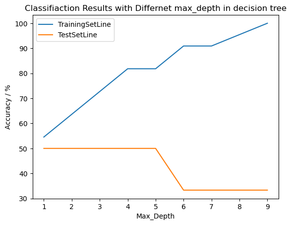

```python
fig, ax = plt.subplots()
df_results_list_dtTrain2.set_index("Max_Depth")["Acc"].plot(ax = ax, label='TrainingSetLine' )
df_results_list_dtTest2.set_index("Max_Depth")["Acc"].plot(ax = ax, label='TestSetLine')
ax.set_title("Classifiaction Results with Differnet max_depth in decision tree")
ax.set_xticks(list(range(1,10,1)))
ax.set_ylabel("Accuracy / %")

ax.legend()

plt.show()
```

# Random Forest

```python
x_cols2 = ["Portugese Ships", "Dutch Ships", "English Ships","Spanish Involvement"]


y_cols2 = ['Portuguese outcome']

X_full2 = Portugesedata[x_cols2]

y_full2 = Portugesedata[y_cols2]

cv_split2 = KFold(n_splits=5, shuffle=True, random_state=371)




# Your code here
for idx_train, idx_test in cv_split2.split(X_full2, y_full2):
    X_train2 = X_full2.iloc[idx_train]
    X_test2 = X_full2.iloc[idx_test]
    y_train2 = y_full2.iloc[idx_train]
    y_test2 = y_full2.iloc[idx_test]
```

```python
results_trainList6 = []
results_testList6 = []
for n_estimator in range(1,150,10):
    np.random.seed(1000)
    depth = 3
    clf_rf = ensemble.RandomForestClassifier(
        n_estimators= n_estimator,
        max_depth = depth)
    accuracy_resultsTrain6 = cross_val_score(clf_rf, X_train2, y_train2.values.ravel(), cv=2, scoring = "accuracy")
    accuracy_resultsTest6 = cross_val_score(clf_rf, X_train2, y_train2.values.ravel(), cv=2, scoring = "accuracy")


    results_trainList6.append([n_estimator, 100 * np.mean(accuracy_resultsTrain6)])
    results_testList6.append([n_estimator, 100 * np.mean(accuracy_resultsTest6)])


df_results_list_dtTrain6 = pd.DataFrame(results_trainList6, columns=["n_estimator", "Acc"])
df_results_list_dtTest6 = pd.DataFrame(results_testList6, columns=["n_estimator", "Acc"])
```

## Random Forest Visualization

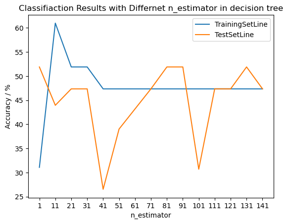

```python
fig, ax = plt.subplots()
df_results_list_dtTrain6.set_index("n_estimator")["Acc"].plot(ax = ax, label='TrainingSetLine')
df_results_list_dtTest6.set_index("n_estimator")["Acc"].plot(ax = ax, label='TestSetLine')
ax.set_title("Classifiaction Results with Differnet n_estimator in decision tree")
ax.set_xticks(list(range(1,150,10)))
ax.set_ylabel("Accuracy / %")

ax.legend()

plt.show()
```

## 3C - Report and compare their results with those from SVM

SVC = When I ran it, the accuracy score attained was a 50% for the test set

Decision Tree = The accuracy score attained was a 50% for the test set

All of these models are very close in comparison for the accuracy score value on the test set. So with a 50% accuracy score these models seem to be guessing causing no significant patterns that can showcase accurate indicators on whether will have portoguese having a winning,losing or draw scenario with all features used.